# PredictionAssignmentWriteup

Auke Beeksma

4 februari 2019

## Data and background

Information about the data and background is found here: http://web.archive.org/web/20161224072740/http:/groupware.les.inf.puc-rio.br/har

## Getting the data and getting it right

split the trainingset into a training and testing part using the proportion 0.7/0.3 as learned this course. Also getting the testdata

```r
library(caret)
```

```r
library(corrplot)
library(randomForest)
library(rattle)
library(rpart)

training_data <- read.csv("c:/Users/auke.beeksma/Desktop/pml-training.csv")
intrain <- createDataPartition(training_data$classe, p = .7, list= FALSE)
training <-training_data[intrain,]
testing <- training_data[-intrain,]
prediction_data <-  read.csv("c:/Users/auke.beeksma/Desktop/pml-testing.csv")
```

# Remove variables which don’t add variance

```r
nsv <- nearZeroVar(training)
training <- (training[, - nsv])
testing <- (testing[, - nsv])
```

# Remove variables with no prediction value. i.e identificationcodes (X, user_name, timestamps)

```r
training <- (training[, - (1:5)])
testing <- (testing[, - (1:5)])
```

# There are many columns with a lot of NA’s. Only work with columns with more then 50% percent is not NA.

```r
training <- training[, -which(colMeans(is.na(training)) > 0.5)]
testing <- testing[, -which(colMeans(is.na(testing)) > 0.5)]
```

# Making three different models with three different methods. Just using with different settings for each method.

The main purpose is to predict “classe” which is a five-class category. Therefore I use three multiclass classification strategies: random forest, rpart, and svm.

# Random forest

```r
set.seed(1337)
train_control <- trainControl(method = "cv", number = 3, verboseIter = FALSE)
model_rf <- train(classe~., method = "rf", data = training, trControl = train_control)
model_rf$finalModel
```

```
##
## Call:
##  randomForest(x = x, y = y, mtry = param$mtry)
##                Type of random forest: classification
##                      Number of trees: 500
## No. of variables tried at each split: 27
##
##         OOB estimate of  error rate: 0.25%
## Confusion matrix:
##      A    B    C    D    E  class.error
## A 3904    1    0    0    1 0.0005120328
## B    8 2647    2    1    0 0.0041384500
## C    0    4 2391    1    0 0.0020868114
## D    0    0    8 2244    0 0.0035523979
## E    0    0    0    9 2516 0.0035643564
```

The estimated error rate is .2% which is really small. Lets use it to predict on the testingdata.

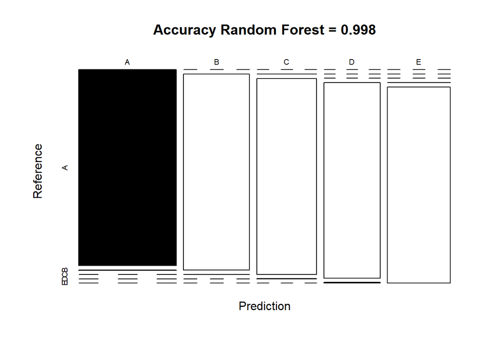

```r
pred_rf <- predict(model_rf, newdata = testing)
pred_matrix_rf <- confusionMatrix(pred_rf, testing$classe)
plot(pred_matrix_rf$table, col = pred_matrix_rf$byClass, main = paste("Accuracy Random Forest =", round(pred_matrix_rf$overall['Accuracy'], 4)))
```

# RPart

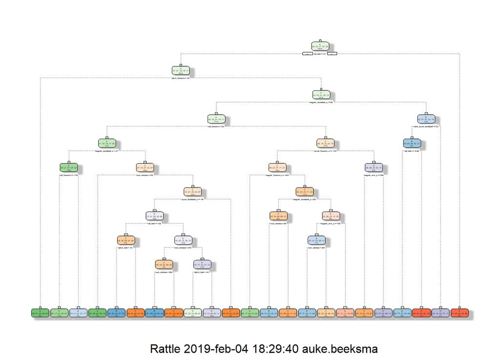

```r
set.seed(1337)
model_rpa <- rpart(classe~., data = training, method = "class")
fancyRpartPlot(model_rpa)
```

A decision tree, now predict it on the testdata.

```r
pred_rpa <- predict(model_rpa, newdata = testing, type = "class")
pred_matrix_rpa <- confusionMatrix(pred_rpa, testing$classe)
pred_matrix_rpa
```

```
## Confusion Matrix and Statistics
##
##           Reference
## Prediction    A    B    C    D    E
##          A 1495  197   33   55   49
##          B   54  671   37   85   97
##          C   20   91  849   89   74
##          D   98  139   72  669  150
##          E    7   41   35   66  712
##
## Overall Statistics
##
##                Accuracy : 0.747
##                  95% CI : (0.7357, 0.7581)
##     No Information Rate : 0.2845
##     P-Value [Acc > NIR] : < 2.2e-16
##
##                   Kappa : 0.6793
##  Mcnemar's Test P-Value : < 2.2e-16
##
## Statistics by Class:
##
##                      Class: A Class: B Class: C Class: D Class: E
## Sensitivity            0.8931   0.5891   0.8275   0.6940   0.6580
## Specificity            0.9207   0.9425   0.9436   0.9067   0.9690
## Pos Pred Value         0.8174   0.7108   0.7560   0.5931   0.8269
## Neg Pred Value         0.9559   0.9053   0.9628   0.9380   0.9264
## Prevalence             0.2845   0.1935   0.1743   0.1638   0.1839
## Detection Rate         0.2540   0.1140   0.1443   0.1137   0.1210
## Detection Prevalence   0.3108   0.1604   0.1908   0.1917   0.1463
## Balanced Accuracy      0.9069   0.7658   0.8855   0.8004   0.8135
```

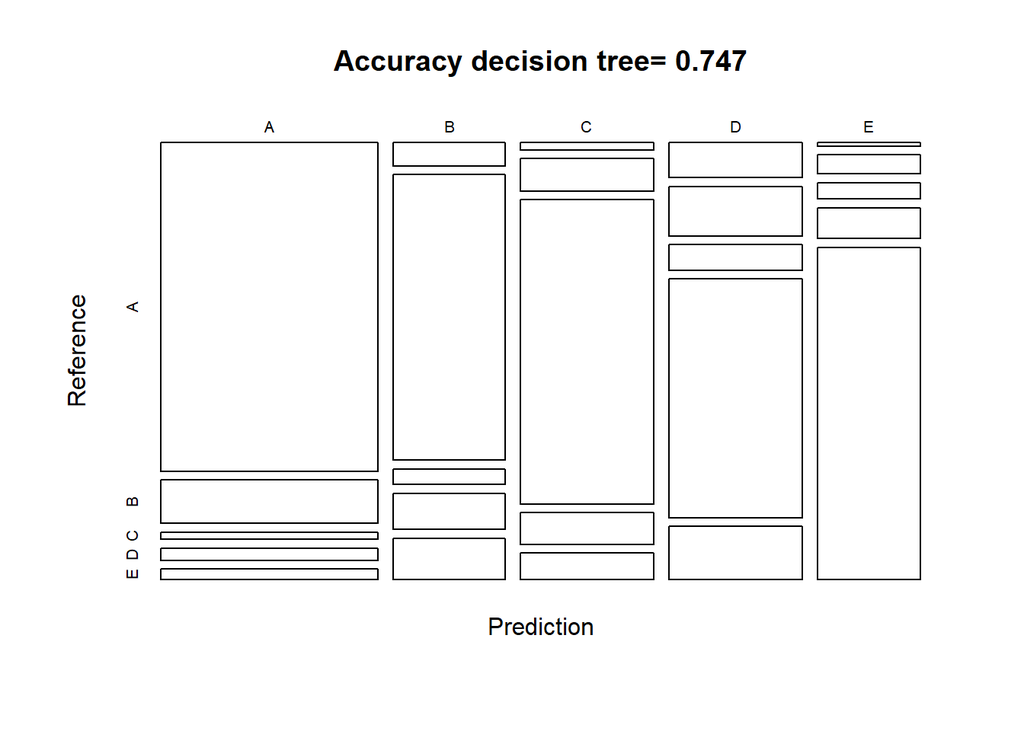

```r
plot(pred_matrix_rpa$table, col = pred_matrix_rpa$byClass,
     main = paste("Accuracy decision tree=",
                  round(pred_matrix_rpa$overall['Accuracy'], 4)))
```